# Using GAN for Generating Hand-written Digit Images

### Label Smoothing

One last point before we start training is the label smoothing which makes the discriminator generalize better [4].

For the real digit images, the labels are all 1s. However, when we train the discriminator, we use a value slightly smaller than 1 with the real digit images. Otherwise, the discriminator might overfit to the training data and rejects anything else that is slightly different from the training images.

### Training Loop

We repeat the following to make both the discriminator and the generator better and better:

- Prepare a batch of real images
- Prepare a batch of fake images generated by the generator using latent samples
- Make the discriminator trainable
- Train the discriminator to classify the real and fake images
- Make the discriminator non-trainable
- Train the generator via the GAN

When training the generator via the GAN, the expect labels are all 1s (real). Initially, the generator produces not very realistic images so the discriminator classifies them as 0s (fake), which causes the back-propagation to adjust the weights inside the generator. The discriminator is not affected as we set it non-trainable in this step.

```python
# hyperparameters
sample_size     = 100     # latent sample size (i.e., 100 random numbers)
g_hidden_size   = 128
d_hidden_size   = 128
leaky_alpha     = 0.01
g_learning_rate = 0.0001  # learning rate for the generator
d_learning_rate = 0.001   # learning rate for the discriminator
epochs          = 100
batch_size      = 64      # train batch size
eval_size       = 16      # evaluate size
smooth          = 0.1

# labels for the batch size and the test size
y_train_real, y_train_fake = make_labels(batch_size)
y_eval_real,  y_eval_fake  = make_labels(eval_size)

# create a GAN, a generator and a discriminator
gan, generator, discriminator = make_simple_GAN(
    sample_size,
    g_hidden_size,
    d_hidden_size,
    leaky_alpha,
    g_learning_rate,
    d_learning_rate)

losses = []
for e in range(epochs):
    for i in range(len(X_train_real)//batch_size):
        # real MNIST digit images
        X_batch_real = X_train_real[i*batch_size:(i+1)*batch_size]

        # latent samples and the generated digit images
        latent_samples = make_latent_samples(batch_size, sample_size)
        X_batch_fake = generator.predict_on_batch(latent_samples)

        # train the discriminator to detect real and fake images
        make_trainable(discriminator, True)
        discriminator.train_on_batch(X_batch_real, y_train_real * (1 - smooth))
        discriminator.train_on_batch(X_batch_fake, y_train_fake)

        # train the generator via GAN
        make_trainable(discriminator, False)
        gan.train_on_batch(latent_samples, y_train_real)

    # evaluate
    X_eval_real = X_test_real[np.random.choice(len(X_test_real), eval_size, replace=False)]

    latent_samples = make_latent_samples(eval_size, sample_size)
    X_eval_fake = generator.predict_on_batch(latent_samples)

    d_loss  = discriminator.test_on_batch(X_eval_real, y_eval_real)
    d_loss += discriminator.test_on_batch(X_eval_fake, y_eval_fake)
    g_loss  = gan.test_on_batch(latent_samples, y_eval_real) # we want the fake to be realistic!

    losses.append((d_loss, g_loss))

    print("Epoch: {:>3}/{} Discriminator Loss: {:>6.4f} Generator Loss: {:>6.4f}".format(
        e+1, epochs, d_loss, g_loss))
```

```
Epoch:   1/100 Discriminator Loss: 0.9538 Generator Loss: 5.5816
Epoch:   2/100 Discriminator Loss: 0.1899 Generator Loss: 2.1410
Epoch:   3/100 Discriminator Loss: 0.3655 Generator Loss: 1.4118
Epoch:   4/100 Discriminator Loss: 0.1344 Generator Loss: 3.0701
Epoch:   5/100 Discriminator Loss: 0.3473 Generator Loss: 2.3738
Epoch:   6/100 Discriminator Loss: 0.5153 Generator Loss: 3.7222
Epoch:   7/100 Discriminator Loss: 0.5159 Generator Loss: 3.5699
Epoch:   8/100 Discriminator Loss: 0.7343 Generator Loss: 2.1149
Epoch:   9/100 Discriminator Loss: 0.4661 Generator Loss: 2.3607
Epoch:  10/100 Discriminator Loss: 0.2888 Generator Loss: 2.4522
Epoch:  11/100 Discriminator Loss: 0.4095 Generator Loss: 1.5612
Epoch:  12/100 Discriminator Loss: 0.5406 Generator Loss: 2.7845
Epoch:  13/100 Discriminator Loss: 0.3287 Generator Loss: 2.6246
Epoch:  14/100 Discriminator Loss: 0.2806 Generator Loss: 2.9350
Epoch:  15/100 Discriminator Loss: 0.6982 Generator Loss: 3.5069
Epoch:  16/100 Discriminator Loss: 0.4339 Generator Loss: 3.3039
Epoch:  17/100 Discriminator Loss: 0.7092 Generator Loss: 1.9226
Epoch:  18/100 Discriminator Loss: 0.8024 Generator Loss: 4.9868
Epoch:  19/100 Discriminator Loss: 0.2961 Generator Loss: 2.8417
Epoch:  20/100 Discriminator Loss: 0.5851 Generator Loss: 3.4906
Epoch:  21/100 Discriminator Loss: 0.3387 Generator Loss: 1.9244
Epoch:  22/100 Discriminator Loss: 0.4378 Generator Loss: 3.1012
Epoch:  23/100 Discriminator Loss: 0.2871 Generator Loss: 2.0432
Epoch:  24/100 Discriminator Loss: 0.3734 Generator Loss: 2.6555
Epoch:  25/100 Discriminator Loss: 0.7119 Generator Loss: 2.8028
Epoch:  26/100 Discriminator Loss: 0.1978 Generator Loss: 2.8457
Epoch:  27/100 Discriminator Loss: 0.5232 Generator Loss: 2.5416
Epoch:  28/100 Discriminator Loss: 0.2756 Generator Loss: 2.2270
Epoch:  29/100 Discriminator Loss: 0.3289 Generator Loss: 3.0124
Epoch:  30/100 Discriminator Loss: 0.5604 Generator Loss: 3.3040
Epoch:  31/100 Discriminator Loss: 0.8915 Generator Loss: 3.2336
Epoch:  32/100 Discriminator Loss: 0.6021 Generator Loss: 1.9195
Epoch:  33/100 Discriminator Loss: 0.4144 Generator Loss: 3.0869
Epoch:  34/100 Discriminator Loss: 0.6223 Generator Loss: 2.1233
Epoch:  35/100 Discriminator Loss: 0.2667 Generator Loss: 2.5386
Epoch:  36/100 Discriminator Loss: 0.3951 Generator Loss: 2.5837
Epoch:  37/100 Discriminator Loss: 0.6367 Generator Loss: 2.4578
Epoch:  38/100 Discriminator Loss: 0.4050 Generator Loss: 2.6965
Epoch:  39/100 Discriminator Loss: 0.3699 Generator Loss: 2.7588
Epoch:  40/100 Discriminator Loss: 0.6437 Generator Loss: 2.1038
```

[output cut: 45 more lines]

```
Epoch:  86/100 Discriminator Loss: 0.8123 Generator Loss: 2.7157
Epoch:  87/100 Discriminator Loss: 0.5252 Generator Loss: 3.1781
Epoch:  88/100 Discriminator Loss: 0.9563 Generator Loss: 2.1756
Epoch:  89/100 Discriminator Loss: 1.0338 Generator Loss: 2.7354
Epoch:  90/100 Discriminator Loss: 0.5451 Generator Loss: 3.0826
Epoch:  91/100 Discriminator Loss: 0.9634 Generator Loss: 3.0830
Epoch:  92/100 Discriminator Loss: 0.7814 Generator Loss: 2.9515
Epoch:  93/100 Discriminator Loss: 0.8324 Generator Loss: 3.5539
Epoch:  94/100 Discriminator Loss: 1.8759 Generator Loss: 1.9687
Epoch:  95/100 Discriminator Loss: 0.9151 Generator Loss: 2.2101
Epoch:  96/100 Discriminator Loss: 0.9279 Generator Loss: 2.2720
Epoch:  97/100 Discriminator Loss: 0.8894 Generator Loss: 3.2808
Epoch:  98/100 Discriminator Loss: 0.9052 Generator Loss: 2.5838
Epoch:  99/100 Discriminator Loss: 0.6043 Generator Loss: 2.9611
Epoch: 100/100 Discriminator Loss: 0.5693 Generator Loss: 2.3100
```

### Stabilizing GAN

As it turns out, training a GAN is quite hard, and there are many tricks and heuristics required [4]. It is because the discriminator and the generator are not cooperating and individually learning to predict better.

For example, the generator might learn to fool the discriminator with garbage. Ideally, the discriminator should learn earlier than the generator so that it can classify images accurately.

Therefore, I used different learning rates for the generator and the discriminator. I wanted to slow down the generator learning so that the discriminator learns to classify well.

I am not 100% certain if this is a generally good strategy to use but it does seem to work in this project.

As the generator learns more and the loss decreases, the discriminator's loss increases. I see kind of equilibrium around 80-90 epochs.

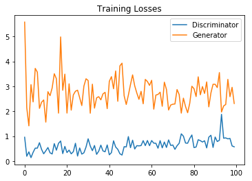

```python
losses = np.array(losses)

fig, ax = plt.subplots()
plt.plot(losses.T[0], label='Discriminator')
plt.plot(losses.T[1], label='Generator')
plt.title("Training Losses")
plt.legend()
plt.show()
```

### Tracking Failures

According to [4],

- The discriminator loss = 0 means something is wrong
- When things are working, the discriminator loss has low variance and goes down over time.
- When things are not working, the discriminator loss has huge variance and spiking
- If the generator loss steadily decreases, it is fooling the discriminator with garbage.

### Don't balance via loss statistics

According to [4],

- i.e., don't try to find a (number of G/number of D) schedule to uncollapse training

## Testing the Generator

Now we generates some digit images using the trained generator.

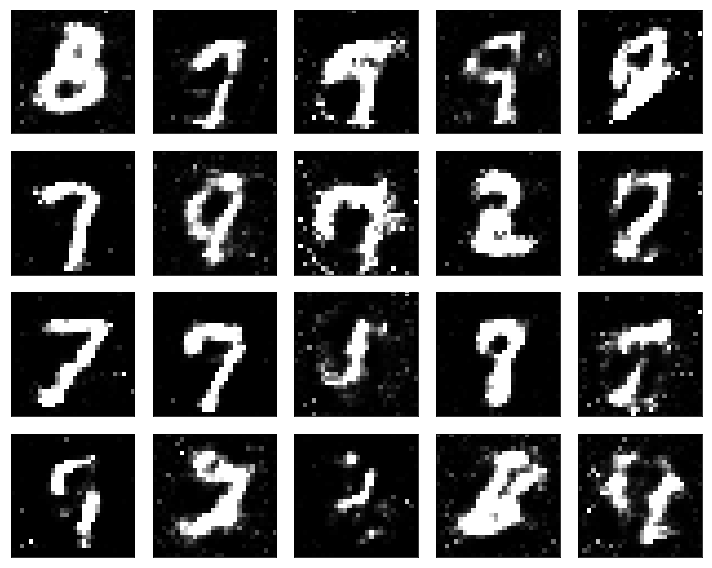

```python
latent_samples = make_latent_samples(20, sample_size)
generated_digits = generator.predict(latent_samples)

plt.figure(figsize=(10, 8))
for i in range(20):
    img = deprocess(generated_digits[i])
    plt.subplot(4, 5, i+1)
    plt.imshow(img, cmap='gray')
    plt.xticks([])
    plt.yticks([])
plt.tight_layout()
plt.show()
```

The results are not outstanding as we are using simple networks. Deep Convolutional GAN (aka DCGAN) would produce better results than this.

## References

### [1] Generative Adversarial Networks

Ian J. Goodfellow, Jean Pouget-Abadie, Mehdi Mirza, Bing Xu, David Warde-Farley, Sherjil Ozair, Aaron Courville, Yoshua Bengio

https://arxiv.org/abs/1406.2661

### [2] GAN MNIST Example in TensorFlow

Udacity

https://github.com/udacity/deep-learning/tree/master/gan_mnist

### [3] MNIST dataset

Yann LeCun

http://yann.lecun.com/exdb/mnist/

### [4] How to Train a GAN? Tips and tricks to make GANs work

Facebook AI Research: Soumith Chintala, Emily Denton, Martin Arjovsky, Michael Mathieu

https://github.com/soumith/ganhacks

https://www.youtube.com/watch?v=X1mUN6dD8uE